# UFCFFY-15-M

# Cyber Security Analytics

## 04: Machine Learning for Cyber Security

#### Prof. Phil Legg

[figure not shown]

# 04: Machine Learning for Cyber Security

In this session we will cover:

- What is Machine Learning?
- What different machine learning approaches are there?
- How do we derive suitable features from our data, to then learn from?

# What is Machine Learning?

[figure not shown]

*A decision model that is not explicitly programmed, but instead is learnt through the training of example data.*

[Machine learning](https://expertsystem.com/machine-learning-definition/) is an application of artificial intelligence (AI) that provides systems the ability to automatically learn and improve from experience **without being explicitly programmed**. Machine learning focuses on the development of computer programs that can access data and use it learn for themselves. We can essentially think of three components: an input (the data), a function, and an output.

The machine is trying to *learn* the function that can map inputs to some form of output, which is achieved by minimising some **error measure** (sometimes described as maximising a fitness function). One possible approach is to consider the difference between the expected output and the predicted output as the error measure - training is the process of iterative steps to reduce this measure.

[figure not shown]

## Generative vs discriminative models

- In **generative models**, given some input data the model will aim to generate new samples (e.g., deepfakes).
- In **discriminative models**, given some input data the model will aim to discriminate between possible classes (e.g. classification).

## Supervised Learning

This is where data is provided with training labels that inform the machine what the data is. For example, if we have a set of images that we wish to classify, we can state that the output is what the image depicts (for example, is it a cat or a dog?). The input to the system is the raw image data assessed based on colour pixel values. The output of the system is a label of either 'cat' or 'dog'. The function that converts the pixel input vector to a label output vector is what the machine attempts to learn. This is often described as **classification**.

## Unsupervised Learning

This is where data is provided however no training labels are given. We want to learn some underlying properties about the data. Examples include **clustering**, where we aim to find hidden distributions within a larger set of data, **association rules** such as those used to identify shopping trends and similarities between consumer groups, and **autoencoders** that aim to learn suitable compression and decompression mechanisms for data representation and feature engineering.

## Other forms of learning

- **semi-supervised** (where we may inform the system only on a subset of samples, as identified through some means which could be unsupervised)
- **active learning** (which involves a human-in-the-loop to label a small subset of data based on some underlying data attributes)
- **reinforcement learning** (which is learning based on trial-and-error, popular for learning to play video games or robotic navigation)

# Methods of Machine Learning

## Linear Regression

- Models *linear* relationship between a dependent variable (y, continuous output) and one or more explanatory (independent) variables (x, numercal input) - e.g., house prices, medical diagnosis, etc...
- $y = m_0 + m_1 X$ (where $m_1$ are learnt weights for each $X$).
- $m_0$ and $m_1$ learnt using Mean Square Error (MSE) and Gradient Descent.

[More detail...](https://towardsdatascience.com/introduction-to-machine-learning-algorithms-linear-regression-14c4e325882a)

[figure not shown]

```python
#https://scikit-learn.org/stable/modules/generated/sklearn.linear_model.LinearRegression.html

import numpy as np
import matplotlib.pyplot as plt
from sklearn.linear_model import LinearRegression
X = np.array([ [1, 1], [1, 2], [2, 2], [2, 3] ])
#X = np.random.random([100,2])
y = np.dot(X, np.array([1, 2])) + 3
reg = LinearRegression().fit(X, y)
print ("X: ", X)
print ("y: ", y)
print ("Score: ", reg.score(X, y))
print ("Co-efficients: ", reg.coef_)
print ("Intecept: ",reg.intercept_)
print ("Prediction: ", reg.predict(np.array([[3, 5]])) )

#plt.scatter(X[:,0], X[:,1])
#plt.show()
```

```
X:  [[1 1]
 [1 2]
 [2 2]
 [2 3]]
y:  [ 6  8  9 11]
Score:  1.0
Co-efficients:  [1. 2.]
Intecept:  3.0000000000000018
Prediction:  [16.]
```

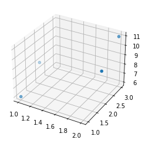

```python
import matplotlib.pyplot as plt
import numpy as np

fig = plt.figure()
ax = fig.add_subplot(projection='3d')

xs = X[:,0]
ys = X[:,1]
zs = y
ax.scatter(xs, ys, zs)
ax.set_xlabel('X Label')
ax.set_ylabel('Y Label')
ax.set_zlabel('Z Label')
plt.show()
```

## Clustering

- Unsupervised approach to find similar datapoints and uncover hidden distributions (e.g., malware families, or malicious v benign).
- **k-means clustering** - identify $k$ unique clusters based on group centroid (mean).

[More detail...](https://en.wikipedia.org/wiki/Cluster_analysis)

[figure not shown]

```
Labels:  [1 1 1 0 0 0]
Predictions:  [1 0]
Centroids:  [[10.  2.]
 [ 1.  2.]]
```

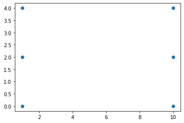

```python
# https://scikit-learn.org/stable/modules/generated/sklearn.cluster.KMeans.html

import numpy as np
import matplotlib.pyplot as plt
from sklearn.cluster import KMeans

X = np.array([[1, 2], [1, 4], [1, 0], [10, 2], [10, 4], [10, 0]])
kmeans = KMeans(n_clusters=2, random_state=42).fit(X)
print ("Labels: ", kmeans.labels_)#
print ("Predictions: ", kmeans.predict([[0, 0], [12, 3]]) )
print ("Centroids: ", kmeans.cluster_centers_)

plt.scatter(X[:,0], X[:,1])
plt.show()
```

## Support Vector Machines

- Supervised approach to identify decision boundary **between** clusters (unlike LR that fits a line through points).
- Measure [euclidean distance](https://en.wikipedia.org/wiki/Euclidean_distance) between data points nearest to the decision boundary and the boundary.
- Optimise the distance of the points from the boundary.

[More detail...](https://en.wikipedia.org/wiki/Support_vector_machine)

[figure not shown]

```
Prediction:  [1]
```

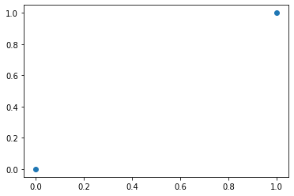

```python
# https://scikit-learn.org/stable/modules/svm.html

from sklearn import svm
X = np.array([[0, 0], [1, 1]])
y = np.array([0, 1])
clf = svm.SVC()
clf.fit(X, y)
print ("Prediction: ", clf.predict(np.array([[2., 2.]])))

plt.scatter(X[:,0], X[:,1])
plt.show()
```

## Dimensionality Reduction

- Principal Component Analysis (PCA) is a common approach (also t-SNE, UMAP)- reduce the dimensionality but preserve the data structure (separability/distance between points).
- Data compression and aids visualisation using **projection** view.
- For a given dataset, PCA finds directions (or vector) of greatest variance - the principal components - used as new axis in $N-1$ space.

[More detail...](https://en.wikipedia.org/wiki/Dimensionality_reduction)

[figure not shown]

```
Original data: #digits: 10  #samples: 1797  #features: 64
```

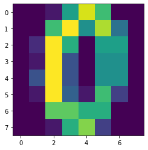

```
Label:  0
```

```python
# https://scikit-learn.org/stable/modules/generated/sklearn.decomposition.PCA.html
# https://scikit-learn.org/stable/auto_examples/cluster/plot_kmeans_digits.html

import numpy as np
import matplotlib.pyplot as plt
from sklearn.datasets import load_digits

data, labels = load_digits(return_X_y=True)
(n_samples, n_features), n_digits = data.shape, np.unique(labels).size

print("Original data: #digits:", n_digits, " #samples:", n_samples, " #features:", n_features)
sample = 10
plt.imshow(data[sample,:].reshape(8,8))
plt.show()
print("Label: ", labels[sample])
```

```
Shape:  (1797, 2)
```

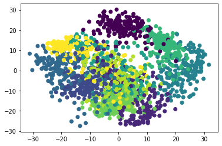

```python
from sklearn.decomposition import PCA
pca = PCA(n_components=2)
result = pca.fit_transform(data)
print ("Shape: ", result.shape)
plt.scatter(result[:,0], result[:,1], c=labels)
# plt.scatter(result[sample,0], result[sample,1], s=200, marker='X', color='red') - show sample in cluster
plt.show()
```

## Neural Networks

- Maps input vector to output vector through [matrix multiplication](https://en.wikipedia.org/wiki/Matrix_multiplication) of weighting functions.
- Feed-forward network: $y = sigmoid (Wx + b)$
- How to resolve error? Backpropagation used to minimise distance between the predicted values and our expected values - the process of "training" the neural network.

[More detail...](https://en.wikipedia.org/wiki/Artificial_neural_network)

[figure not shown]

```python
# https://scikit-learn.org/stable/modules/generated/sklearn.neural_network.MLPClassifier.html

from sklearn.neural_network import MLPClassifier
from sklearn.datasets import make_classification
from sklearn.model_selection import train_test_split
X, y = make_classification(n_samples=100, random_state=1)
X_train, X_test, y_train, y_test = train_test_split(X, y, stratify=y, random_state=42)
clf = MLPClassifier(random_state=1, max_iter=300).fit(X_train, y_train)
print ("Prediction (Probability): ", clf.predict_proba(X_test[:1]))
print ("Prediction (Class Label): ", clf.predict(X_test[:5, :]))
print ("Accuracy: ", clf.score(X_test, y_test))
```

```
Prediction (Probability):  [[0.00415509 0.99584491]]
Prediction (Class Label):  [1 1 1 0 1]
Accuracy:  0.96
```

# Feature Engineering

How should we present data to a classifier?

- Images/Video: Pixel data
- PCAP: Src? Dest? Port? Protocol? *No single right answer...*
- Files: File size? Ordered bytes? Process calls? *Anything else?*

What about **sequential** data such as text?

- [n-grams](https://en.wikipedia.org/wiki/N-gram): sliding window of $n$-items in data (e.g. *'The cat', 'cat sat', 'sat on', 'on the', 'the mat'*). Count occurrence of $n$ ordered entities. Can be used at word or character level.

[More on Statistical Analysis - SDAV](http://www.cems.uwe.ac.uk/~pa-legg/sdav/book/03-statistics.html)

[More on Text Analytics - SDAV](http://www.cems.uwe.ac.uk/~pa-legg/sdav/book/07-textanalytics.html)

# More on Text Analysis

- https://chat.openai.com/chat
- https://en.wikipedia.org/wiki/BERT_(language_model)
- https://scikit-learn.org/stable/tutorial/text_analytics/working_with_text_data.html
- https://pypi.org/project/transformers/
- [Ashish Vaswani, Noam Shazeer, Niki Parmar, Jakob Uszkoreit, Llion Jones, Aidan N. Gomez, Lukasz Kaiser, Illia Polosukhin. "Attention Is All You Need" NIPS, 2017](https://research.google/pubs/pub46201/)

# Further Reading

- [M. A. Ayub, S. Smith, A. Siraj and P. Tinker, "Domain Generating Algorithm based Malicious Domains Detection," 2021 8th IEEE International Conference on Cyber Security and Cloud Computing (CSCloud)](https://ieeexplore.ieee.org/document/9492239)
- [Daniele Ucci, Leonardo Aniello and Roberto Baldoni, "Survey of machine learning techniques for malware analysis" Computers and Security, Volume 81, March 2019, Pages 123-147](https://www.sciencedirect.com/science/article/pii/S0167404818303808)
- [Andrew Y. Ng and Michael I. Jordan. "On Discriminative vs. Generative classifiers: A comparison of logistic regression and naive Bayes" Advances in Neural Information Processing Systems, 2002](https://proceedings.neurips.cc/paper/2001/file/7b7a53e239400a13bd6be6c91c4f6c4e-Paper.pdf)
- [M. Rhode, P. Burnap and K. Jones, “Early-stage malware prediction using recurrent neural networks”. Computers & Security, Volume 77, August 2018, Pages 578-594.](https://www.sciencedirect.com/science/article/pii/S0167404818305546)
- [A. Mills, T. Spyridopoulos and P. Legg, “Efficient and Interpretable Real-Time Malware Detection Using Random-Forest,” 2019 International Conference on Cyber Situational Awareness, Data Analytics And Assessment (Cyber SA), 2019, pp. 1-8, doi: 10.1109/CyberSA.2019.8899533.](https://ieeexplore.ieee.org/abstract/document/8899533)

# Practical Session

1. Try the [04-Machine Learning](http://www.cems.uwe.ac.uk/~pa-legg/csa/lab/lab-04-basic_ml.html) lab examples
2. Explore the [scikit-learn library](https://scikit-learn.org/stable/index.html) library
3. Release of [Assignment Portfolio Task 2](http://www.cems.uwe.ac.uk/~pa-legg/csa/assignment/task02.html)